# E. coli Technical Report

Ethan Ashby, Annie Cohen, Lian Morales, Prof. Jo Hardin, Prof. Dan Stoebel, Prof. Danae Schulz

7/22/2019

# **1** Introduction

### **1.1** Background on E. coli

E. coli possesses a general stress response to a variety of environmental stresses (Battesti *et al* 2011, Hengge 2011) ranging from osmotic shock to nutrient starvation. A key transcription factor coordinating this response is RpoS, which regulates one quarter of the bacteria’s genome (preliminary data from Professor Dan Stoebel). Simple interpretations of transcriptional networks often invoke an analogy of an on/off switch, in which the presence of a stimulus turns some genes on and other genes off. However, these simple interpretations don’t adequately describe the complex, dyanmic processes underlying many transcriptional responses to stimuli. Currently, there exists a limited understanding regarding the dynamic nature of transcriptional responses, and the well-annotated, heavily-studied genome of E. coli presents an excellent model to study these intricate regulatory circuits.

### **1.2** RNA-Seq

RNA-Seq is the process of extracting, fragmenting, amplifying, and mapping RNA to a reference gene in order to determine gene expression levels. Sequencing of RNA data allows us to determine how RpoS regulates genes in response to a stressor such as starvation. We use RNA-Seq to compare the gene expression levels across treatments and time points. We are interested in both the differences in expression between our treatment samples, wildtype (WT), and our control (dRpoS), as well as the differential expression of WT from 0 to 150 minutes of starvation.

### **1.3** Our data

The data that we recieved from Professor Stoebel and his lab is in the format of a count matrix, with 37 columns. The column names specify the strain, timepoint, treatment, and replicate of the sample. “JH_01” or “JH_02” specifies the strain of *E. coli*, where “JH_01” is the wildtype under starvation, our treatment, and “JH_02” is delta-RpoS, our control in which RpoS is removed from the cells, under starvation. “A”, “B”, and “C” denotes the biological replicate and the number following it indicates the time point: “01” is 0, “02” is 30, “03” is 60, “04” is 90, “05” is 120, and “06” is 150 minutes. The original data came with a column called “Geneid”, which denotes the specific gene. However, we needed a matrix of count data in order to normalize our data, so we assigned this column as the row names and then deleted the column. $~$

```r
# import data
ec_rawcounts <- read.table("LB_Time_Course_GCA_000005845.2_ASM584v2_genomic_counts.txt", header = TRUE)

# ID gene names using Madison's parsing code
rownames(ec_rawcounts) <- ec_rawcounts$Geneid
bnum = "b[0-9]{4}"
ec_rawcounts$GeneidBackup = ec_rawcounts$Geneid
ec_rawcounts <- ec_rawcounts %>%
  separate(GeneidBackup, c("feature", "rest"), sep="[:]")
ec_rawcounts <- ec_rawcounts %>%
  filter(feature %in% c("CDS"))
genename = ":[a-z]{3}.."
ec_cds <- ec_rawcounts %>%
  filter(feature %in% c("CDS"))
ec_rawcounts$genename <- str_extract(ec_rawcounts$Geneid, genename)
ec_rawcounts$bnum <- str_extract(ec_rawcounts$Geneid, bnum)
ec_rawcounts <- ec_rawcounts %>%
  separate(genename, into = c("colon", "genename"), sep = ":") %>%
  dplyr::select(-c(colon, rest, feature, bnum))
# de dupe genenames
ec_rawcounts <- distinct(ec_rawcounts, genename, .keep_all = TRUE)

# assign Geneid as rownames and delete variable
rownames(ec_rawcounts) <- ec_rawcounts$genename
ec_rawcounts <- ec_rawcounts %>% dplyr::select(-c(Geneid, genename))
```

$~$

# **2** Normalization

Normalization is an extremely influential step in the process of determining differentially expressed genes. It is necessary in order to minimize external factors such as gene length and sequencing depth. If a gene is longer, there is a higher probability of having more reads because of its longer sequence. Similarly, if one sample has disproportionately more reads than another, it will return a false positive. Therefore, we must normalize for both gene length and sequencing depth.

We tested out many normalization methods including DESeq2 and edgeR. DESeq2 is a normalization and differential expression analysis method that divides counts by size factors that are calculated as the median of the ratios of read counts to the geometric mean. EdgeR employs the trimmed mean method (TMM), where gene expression is adjusted by a size factor that takes into account the fold change and relative expression level to its sample (Ciaran et. al). Through a comparison of size factors, we determined that the two methods produced very similar normalized counts. We ultimately decided to use DESeq2 because of its abundant documentation.

$~$

```r
# prepare for DESeq2
ec_coldata <- data.frame(names = colnames(ec_rawcounts)) %>%
  separate(names, c("treat", "rep_time"), "_") %>%
  mutate(rep = ifelse(substr(rep_time,start=1,stop = 1) == "A", 1,
                        ifelse(substr(rep_time,start=1,stop = 1) == "B", 2, 3))) %>%
  mutate(time = ifelse(substr(rep_time,start=3,stop = 3) == "1", 0,
                      ifelse(substr(rep_time,start=3,stop = 3) == "2", 30,
                             ifelse(substr(rep_time,start=3,stop = 3) == "3", 60,
                                    ifelse(substr(rep_time,start=3,stop = 3) == "4", 90,
                                           ifelse(substr(rep_time,start=3,stop = 3) == "5", 120, 150)))))) %>%
  mutate(treat = ifelse(treat == "JH01", "WT","dRpoS")) %>%
  mutate(timetreat = paste(treat,time,sep = "")) %>%
  dplyr::select(-rep_time)
rownames(ec_coldata) <- colnames(ec_rawcounts)
```

DESeq2 normalizes data within the differential expression analysis function pipeline, so we first run DESeq() and then extract the normalized counts:

```r
ec_dds <- DESeqDataSetFromMatrix(ec_rawcounts, colData = ec_coldata, design = ~ timetreat)
ec_dds_de <- DESeq(ec_dds)
ec_normcounts <- as.data.frame(counts(ec_dds_de, normalized=TRUE))
```

$~$

# **3** Differential Expression

### **3.1** DESeq2

Because we have already run DESeq() above, we can now extract the significant results. We chose a p-value of 0.01 to be consistent across all of our work.

```r
EC_sig_genes <- c()

# determine the genes that are differentially expressed between WT0 and WT150
de_results <- results(ec_dds_de, contrast = c("timetreat", "WT150","WT0"))
resSig <- de_results[ which(de_results$padj < 0.01 ), ]
resSig$genename <- rownames(resSig)
ind <- match(rownames(ec_normcounts),resSig$genename)
ec_normcounts$sig <- resSig$genename[ind]
EC_sig_genes$WT_compare <- ec_normcounts %>%
 filter(!is.na(ec_normcounts$sig))


# determine the genes that are differentially expressed between WT150 and dRpoS150
de_results <- results(ec_dds_de, contrast = c("timetreat", "WT150","dRpoS150"))
resSig <- de_results[ which(de_results$padj < 0.01 ), ]
resSig$genename <- rownames(resSig)
ind <- match(rownames(ec_normcounts),resSig$genename)
ec_normcounts$sig <- resSig$genename[ind]
EC_sig_genes$treat_compare <- ec_normcounts %>%
 filter(!is.na(ec_normcounts$sig))

# find the intersection of the two lists of differentially expressed genes
EC_sig_genes <- intersect(EC_sig_genes$WT_compare$sig, EC_sig_genes$treat_compare$sig)
```

### **3.2** ImpulseDE2

ImpulseDE2 is a serial method for differential expression that models data based on the impulse model, which has parameters $t_1, t_2, h_0, h_1, \text{and } b.$ The impulse model has a spike, characterized by its beginning height, $h_0$, inflection point, $t_1$, its height, $h_1$, and its slope at $t_1$, $b$. Then the model decreases into its steady state, characterized by the second inflection point, $t_2$, and its final height, $h_2$.

ImpulseDE2 determines differential expression by: (1) running DESeq2 and adjusting gene-wise dispersion estimates from DESeq2 to fit a curve (2) computing size factors and normalizing counts (3) fitting null and alternative model to each of the genes (4) fitting sigmoid model to the treatment condition. In our case, cells with RpoS. (5) determining differential expression analysis based on these models fits to each gene

```r
ec_design <- data.frame(Sample=colnames(ec_rawcounts),
                        Condition=c(rep("case",6), rep("control",6), rep("case",6), rep("control",6), rep("case",6), rep("control",6)),
                        Time=rep(c(0,30,60,90,120,150),6))
```

```r
impulse_ecoli <- ImpulseDE2::runImpulseDE2(as.matrix(ec_rawcounts), ec_design, boolCaseCtrl=TRUE, vecConfounders=NULL, scaQThres = 0.01, scaNProc = 8, boolIdentifyTransients = TRUE)
```

### **3.3** maSigPro

```r
# set up design
Time <- rep(c(0,30,60,90,120,150),6)
Replicate <- rep(1:3, 12)
Control <- c(rep(0, 6), rep(1, 6), rep(0, 6), rep(1, 6), rep(0, 6), rep(1,6))
d_Rpos <- c(rep(1, 6), rep(0, 6), rep(1, 6), rep(0, 6), rep(1, 6), rep(0, 6))
ec_design <- cbind(Time, Replicate, Control, d_Rpos)
rownames(ec_design) <- colnames(ec_rawcounts)

# run maSigPro on DESeq2 Normalized Counts, theta=10, Q=0.01
ec_normcounts <- as.data.frame(counts(ec_dds_de, normalized=TRUE))
ec_design <- make.design.matrix(ec_design, degree=5)
```

```r
# ID DEGs
fits <- p.vector(ec_normcounts, ec_design, Q=0.01, MT.adjust = "BH", min.obs=6, counts=TRUE)
#variable selection procedure to ID variables for each gene
tsep <- T.fit(fits, step.method = "backward", alfa=0.01)

# Get sig genes between delta_RpoS and Control
sigs <- get.siggenes(tsep, rsq = 0.6, vars = "groups")
maSigProGenes<-sigs$summary$d_RposvsControl
```

$~$

### **3.4** Find the Intersection

```r
# Intersect each gene list with another method to calculate gene list of DEGs found in 2 < methods

DS_IM <- distinct(data.frame("genename" = intersect(EC_sig_genes, impulse_ecoli$vecDEGenes)))
IM_MA <- distinct(data.frame("genename" = intersect(impulse_ecoli$vecDEGenes, maSigProGenes)))
MA_DS <- distinct(data.frame("genename" = intersect(maSigProGenes, EC_sig_genes)))
EC_DEGs <- distinct(bind_rows(DS_IM, IM_MA, MA_DS))
```

This is a visualization of the overlap between these three methods. Our `EC_DEGs` list is a compilation of genes that overlap between two or more methods:

$~$

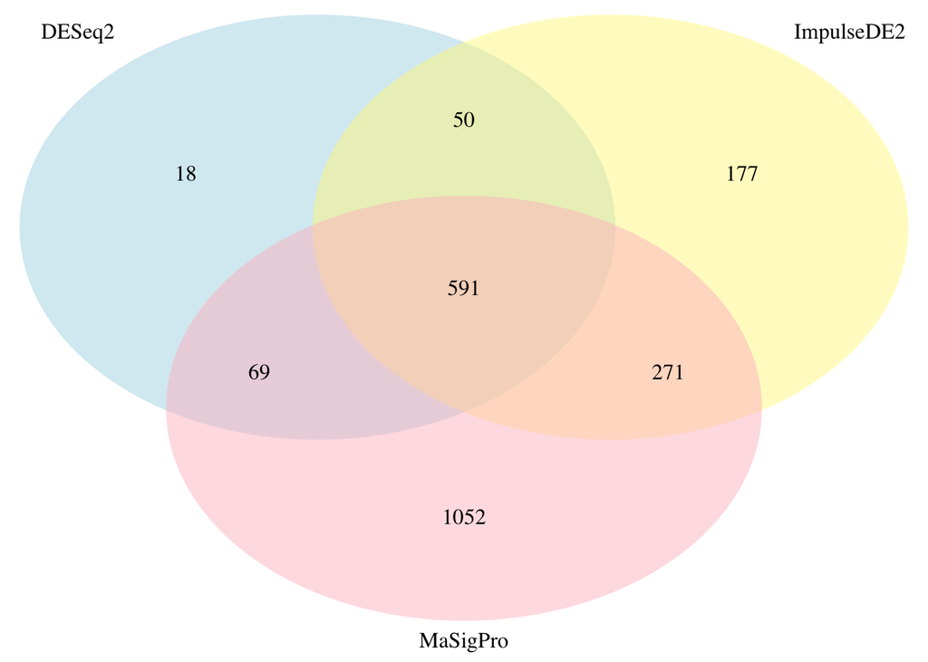

[output not shown]

# **4** Visualization

### **4.1** ggplot2

We used ggplot2 for the standard visualization of the differentially expressed genes’ expression over time.

First, we prepared the list of differentially expressed genes `EC_DEGs` to be tidied:

```r
ec_normcounts$genename <- rownames(ec_normcounts)
EC_DEGs <- left_join(EC_DEGs, ec_normcounts, by = "genename")
#EC_DEGs <- EC_DEGs %>%
#  dplyr::select(-sig)
```

Then we tidied the data using `gather()` and other functions from the tidyr package. We also use group_by() to calculate the average count across all three biological replicates:

```r
EC_counts_gath <- EC_DEGs %>%
  gather(-genename, key="sample", value = "rawcount") %>%
  separate(sample, c("treat", "rep_time"), "_") %>%
  mutate(rep = ifelse(substr(rep_time,start=1,stop = 1) == "A", 1,
                        ifelse(substr(rep_time,start=1,stop = 1) == "B", 2, 3))) %>%
  mutate(time = ifelse(substr(rep_time,start=3,stop = 3) == "1", 0,
                      ifelse(substr(rep_time,start=3,stop = 3) == "2", 30,
                             ifelse(substr(rep_time,start=3,stop = 3) == "3", 60,
                                    ifelse(substr(rep_time,start=3,stop = 3) == "4", 90,
                                           ifelse(substr(rep_time,start=3,stop = 3) == "5", 120, 150)))))) %>%
  mutate(treat = ifelse(treat == "JH01", "WT","dRpoS")) %>%
  dplyr::select(-c(rep_time))

EC_counts_ave <- EC_counts_gath %>%
  group_by(genename, treat, time) %>%
  dplyr::summarise(avecount = mean(rawcount)) %>%
  filter(treat == "WT")
colnames(EC_counts_ave) <- c("genename", "treat", "time", "avecount")
```

Finally, we plot the tidy data using ggplot() :

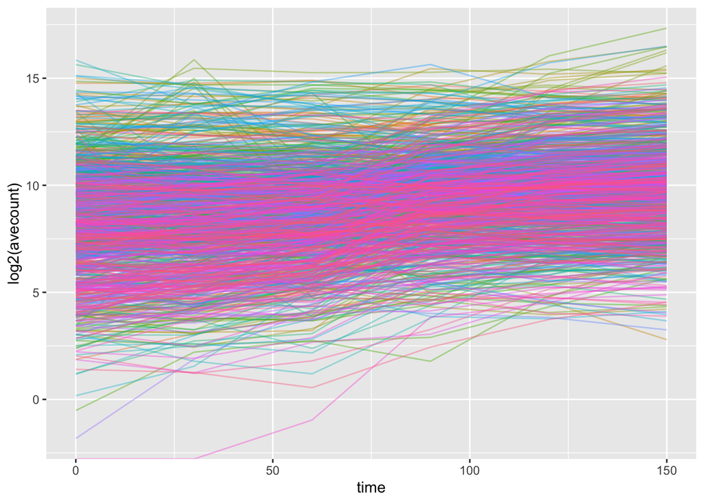

```r
EC_counts_ave %>%
  ggplot(aes(x=time, y=log2(avecount))) +
  geom_line(aes(color = genename), alpha = 0.4) +
  theme(legend.position = "none")
```

# **5** Analysis

### **5.1** PAM Clustering

Partitioning Around Medoids (PAM) is a clustering method iteratively groups genes into clusters of genes with similar profiles. For our code, we input a dissimilarity matrix, which is a matrix of the correlation between each gene, based on their counts. We specified the correlation method as “spearman”, however “pearson” returns similar results. The PAM method chooses k center genes (medoids) and assigns all of the rest of the genes to the closest medoids New medoids are calculated from these clusters and the cycle is repeated until the clusters and medoids stay the same between iterations.

First, compute an optimal k number of clusters. This package `NbClust` runs through 30 different tests that each determine the optimal k and plots the distribution of all 30 of the optimal k results in order to determine the most common result and the **MOST** optimal k.

```r
library(NbClust)

rownames(EC_DEGs) <- EC_DEGs$genename
EC_DEGs <- EC_DEGs %>%
  dplyr::select(-genename)

#k_test <- NbClust(data = EC_DEGs, diss = NULL, distance = "euclidean", min.nc = 2, max.nc = 20, method = "kmeans")
```

Then use the PAM method to cluster the DEGs’ count data:

```r
k = 6

# calculate the dissimilarity matrix. use the transpose of the count matrix because we want all of the genes as columns in order to calculate the correlation.
dissimilarity_matrix <- 1 - cor(t(EC_DEGs), method = "spearman")

# run the pam() function which clusters the data. the pamonce parameter speeds up the function by maximizing short cuts.
EC_DESeq_clusters <- cluster::pam(x = dissimilarity_matrix, k = k, pamonce = 5)

# create a data table with the cluster name and Geneid
gene_cluster <- data.frame("cluster" = EC_DESeq_clusters$clustering, "genename" = names(EC_DESeq_clusters$clustering))

# make a data frame with the names of the medoid for each of the k clusters
EC_PAM_medoids <- data.frame("genename" = rownames(EC_DESeq_clusters$medoids))

ec_norm_counts <- ec_normcounts %>%
  mutate("genename" = rownames(ec_normcounts))

# join the normalized counts with the clusters of genes by their Geneid
EC_cluster_df <- left_join(gene_cluster, ec_norm_counts, by = "genename") #%>%
  #dplyr::select(-sig)
```

Now, we will standardize our data using the `Mfuzz` package’s standardise() function. The function standardizes the data so that each gene has a mean expression of 0 and a standard deviation of 1. We standardize our data in order to visualize and understand the profiles within each cluster.

```r
cluster_standard <- EC_cluster_df %>%
  dplyr::select(-cluster)
rownames(cluster_standard) <- cluster_standard$genename
cluster_standard <- cluster_standard %>%
  dplyr::select(-genename)

# create a phenotype data frame, which describes the conditions/columns of the mnain data frame.
metadata <- data.frame(labelDescription = c("treat", "rep", "time", "timetreat"))
phenoData <- new("AnnotatedDataFrame", data=ec_coldata, varMetadata=metadata)

# convert the gene expression data frame to a matrix
clusters <- as.matrix(cluster_standard)

# create an object of type ExpressionSet
eset <- Biobase::ExpressionSet(assayData = clusters, phenoData = phenoData)

# plug ExpressionSet object into the standardise() function and extract the standardized matrix and convert it into a data frame
cluster_standardized <- Mfuzz::standardise(eset = eset)
standard_clusters <- data.frame(cluster_standardized@assayData$exprs)
standard_clusters$genename <- rownames(standard_clusters)

# join the cluster data with the standardized expression counts
clusters <- left_join(standard_clusters, gene_cluster, by = "genename")
```

Then we tidied the standardized data using gather() and other functions from the `tidyr` package. We also use group_by() to calculate the average count across all three biological replicates.

```r
EC_counts_gath <- clusters %>%
  gather(-c(genename, cluster), key="sample", value = "rawcount") %>%
  separate(sample, c("treat", "rep_time"), "_") %>%
  mutate(rep = ifelse(substr(rep_time,start=1,stop = 1) == "A", 1,
                        ifelse(substr(rep_time,start=1,stop = 1) == "B", 2, 3))) %>%
  mutate(time = ifelse(substr(rep_time,start=3,stop = 3) == "1", 0,
                      ifelse(substr(rep_time,start=3,stop = 3) == "2", 30,
                             ifelse(substr(rep_time,start=3,stop = 3) == "3", 60,
                                    ifelse(substr(rep_time,start=3,stop = 3) == "4", 90,
                                           ifelse(substr(rep_time,start=3,stop = 3) == "5", 120, 150)))))) %>%
  mutate(treat = ifelse(treat == "JH01", "WT","dRpoS")) %>%
  dplyr::select(-c(rep_time))

EC_counts_sum <- EC_counts_gath %>%
  group_by(genename, cluster, treat, time) %>%
  dplyr::summarise(avecount = mean(rawcount)) %>%
  filter(treat == "WT") %>%
  filter(!is.na(cluster))
colnames(EC_counts_sum) <- c("genename", "cluster", "treat", "time", "avecount")
```

```r
# create a data frame that joins the medoid gene names and their standardized expression values
EC_medoid_df <- left_join(EC_PAM_medoids, clusters, by = "genename") %>%
  dplyr::select(-cluster) %>%
  mutate(cluster = c(1:6))

# tidy medoid data (same pipeline as all count tidying)
EC_counts_gath_med <- EC_medoid_df %>%
  gather(-c(genename, cluster), key="sample", value = "rawcount") %>%
  separate(sample, c("treat", "rep_time"), "_") %>%
  mutate(rep = ifelse(substr(rep_time,start=1,stop = 1) == "A", 1,
                        ifelse(substr(rep_time,start=1,stop = 1) == "B", 2, 3))) %>%
  mutate(time = ifelse(substr(rep_time,start=3,stop = 3) == "1", 0,
                      ifelse(substr(rep_time,start=3,stop = 3) == "2", 30,
                             ifelse(substr(rep_time,start=3,stop = 3) == "3", 60,
                                    ifelse(substr(rep_time,start=3,stop = 3) == "4", 90,
                                           ifelse(substr(rep_time,start=3,stop = 3) == "5", 120, 150)))))) %>%
  mutate(treat = ifelse(treat == "JH01", "WT","dRpoS")) %>%
  dplyr::select(-c(rep_time))

EC_counts_sum_med <- EC_counts_gath_med %>%
  group_by(genename, cluster, treat, time) %>%
  dplyr::summarise(avecount = mean(rawcount)) %>%
  filter(treat == "WT")
colnames(EC_counts_sum_med) <- c("genename", "cluster", "treat", "time", "avecount")
```

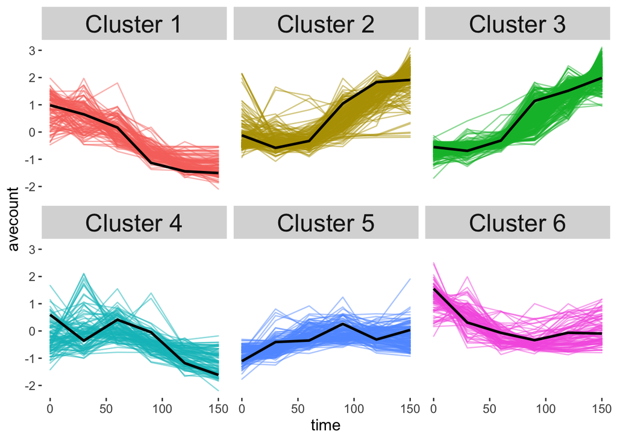

```r
# plot standardized clusters (facet_wrapped) with medoids
EC_counts_sum %>%
  ggplot(aes(x=time, y=avecount)) +
  geom_line(aes(group = genename, color = as.factor(cluster)), lineend = "round" , alpha = 0.5) +
  facet_wrap(~factor(cluster, labels = c("Cluster 1", "Cluster 2", "Cluster 3", "Cluster 4", "Cluster 5", "Cluster 6"))) + geom_line(data = EC_counts_sum_med, aes(x=time, y=avecount, group = genename), size = 1) +
  theme(legend.position = "none", panel.background = element_blank(), strip.text = element_text(size = 20), axis.title = element_text(size = 13), axis.text = element_text(size = 10))
```

Create a list of the clusters with their genes:

```r
cluster_genes <- data.frame("genename" = gene_cluster$genename)
rownames(cluster_genes) <- cluster_genes$genename
cluster_genes <- left_join(cluster_genes, gene_cluster, by = "genename") %>%
  filter(!is.na(genename))
rownames(cluster_genes) <- cluster_genes$genename

#list of data frames with gene names for each cluster
EC_cluster <- c()
EC_cluster$cluster1 <- cluster_genes %>%
  filter(cluster == 1) %>%
  dplyr::select(genename)
EC_cluster$cluster2 <- cluster_genes %>%
  filter(cluster == 2) %>%
  dplyr::select(genename)
EC_cluster$cluster3 <- cluster_genes %>%
  filter(cluster == 3) %>%
  dplyr::select(genename)
EC_cluster$cluster4 <- cluster_genes %>%
  filter(cluster == 4) %>%
  dplyr::select(genename)
EC_cluster$cluster5 <- cluster_genes %>%
  filter(cluster == 5) %>%
  dplyr::select(genename)
EC_cluster$cluster6 <- cluster_genes %>%
  filter(cluster == 6) %>%
  dplyr::select(genename)
```

### **5.2** GO Analysis

Run TopGo for GO

```r
go_enrich <- function(go_type, k) {
  selection <- function(k) {
    gene_clust <- cluster_genes$cluster == k
    return(gene_clust)
    }
  GeneList <- factor(as.integer(selection(k)))
  names(GeneList) <- cluster_genes$genename
  annot <- annFUN.org(whichOnto = go_type, feasibleGenes = NULL, mapping = "org.EcK12.eg", ID = "symbol")
  GOdata <- new("topGOdata", ontology=go_type, allGenes=GeneList, annot=annFUN.GO2genes, GO2genes = annot, geneSelectionFun = selection, nodeSize = 5)
  resultFis <- runTest(GOdata, algorithm = "classic", statistic = "fisher")
  #resultKS <- runTest(GOdata, algorithm = "classic", statistic = "ks")
  goEnrich <- GenTable(GOdata, fisherPval = resultFis, topNodes = 30)
  #ind <- match(goEnrich$GO.ID, names(annot))
  #goEnrich$Gene <- annot[ind]
  return(goEnrich)
}

bp <- go_enrich("BP", 1) %>%
  mutate("Type" = "Biological Process")
mf <- go_enrich("MF", 1) %>%
  mutate("Type" = "Molecular Function")
cc <- go_enrich("CC", 1) %>%
  mutate("Type" = "Cellular Component")
cluster1_genes <- bind_rows(bp, mf, cc)

bp <- go_enrich("BP", 2) %>%
  mutate("Type" = "Biological Process")
mf <- go_enrich("MF", 2) %>%
  mutate("Type" = "Molecular Function")
cc <- go_enrich("CC", 2) %>%
  mutate("Type" = "Cellular Component")
cluster2_genes <- bind_rows(bp, mf, cc)

bp <- go_enrich("BP", 3) %>%
  mutate("Type" = "Biological Process")
mf <- go_enrich("MF", 3) %>%
  mutate("Type" = "Molecular Function")
cc <- go_enrich("CC", 3) %>%
  mutate("Type" = "Cellular Component")
cluster3_genes <- bind_rows(bp, mf, cc)

bp <- go_enrich("BP", 4) %>%
  mutate("Type" = "Biological Process")
mf <- go_enrich("MF", 4) %>%
  mutate("Type" = "Molecular Function")
cc <- go_enrich("CC", 4) %>%
  mutate("Type" = "Cellular Component")
cluster4_genes <- bind_rows(bp, mf, cc)

bp <- go_enrich("BP", 5) %>%
  mutate("Type" = "Biological Process")
mf <- go_enrich("MF", 5) %>%
  mutate("Type" = "Molecular Function")
cc <- go_enrich("CC", 5) %>%
  mutate("Type" = "Cellular Component")
cluster5_genes <- bind_rows(bp, mf, cc)

bp <- go_enrich("BP", 6) %>%
  mutate("Type" = "Biological Process")
mf <- go_enrich("MF", 6) %>%
  mutate("Type" = "Molecular Function")
cc <- go_enrich("CC", 6) %>%
  mutate("Type" = "Cellular Component")
cluster6_genes <- bind_rows(bp, mf, cc)

GO_clusters <- c()
GO_clusters$cl1 <- cluster1_genes
GO_clusters$cl2 <- cluster2_genes
GO_clusters$cl3 <- cluster3_genes
GO_clusters$cl4 <- cluster4_genes
GO_clusters$cl5 <- cluster5_genes
GO_clusters$cl6 <- cluster6_genes
```

### **5.3** GSEA

```r
impulse_pval <- data.frame("genename" = impulse_ecoli$dfImpulseDE2Results$Gene, "padj" = impulse_ecoli$dfImpulseDE2Results$padj)

ec_Stat <- impulse_pval

stat_all <- ec_Stat$padj
names(stat_all) <- ec_Stat$genename

cluster1 <- left_join(EC_cluster$cluster1,ec_Stat, by = "genename") %>%
  filter(!is.na(genename))
stat_cluster1 <- cluster1$padj
names(stat_cluster1) <- cluster1$genename

cluster2 <- left_join(EC_cluster$cluster2,ec_Stat, by = "genename") %>%
  filter(!is.na(genename))
stat_cluster2 <- cluster2$padj
names(stat_cluster2) <- cluster2$genename

cluster3 <- left_join(EC_cluster$cluster3,ec_Stat, by = "genename") %>%
  filter(!is.na(genename))
stat_cluster3 <- cluster3$padj
names(stat_cluster3) <- cluster3$genename

cluster4 <- left_join(EC_cluster$cluster4,ec_Stat, by = "genename") %>%
  filter(!is.na(genename))
stat_cluster4 <- cluster4$padj
names(stat_cluster4) <- cluster4$genename

cluster5 <- left_join(EC_cluster$cluster5,ec_Stat, by = "genename") %>%
  filter(!is.na(genename))
stat_cluster5 <- cluster5$padj
names(stat_cluster5) <- cluster5$genename

cluster6 <- left_join(EC_cluster$cluster6,ec_Stat, by = "genename") %>%
  filter(!is.na(genename))
stat_cluster6 <- cluster6$padj
names(stat_cluster6) <- cluster6$genename

sens <- read_csv("past_sensitivity.csv") %>%
  dplyr::select(c(geneName,bNum, `Differentially expressed between 0% and 100% RpoS`,`Direction of regulation`, sensitivity)) %>%
  filter(`Differentially expressed between 0% and 100% RpoS` == TRUE) %>%
  dplyr::select(-`Differentially expressed between 0% and 100% RpoS`)

sens_name <- c()
sens_name$sensitive <- sens$geneName[which(sens$sensitivity=="sensitive")]
sens_name$insensitive <- sens$geneName[which(sens$sensitivity=="insensitive")]
sens_name$linear <- sens$geneName[which(sens$sensitivity=="linear")]

fgsea(sens_name, stat_all, minSize = 1, maxSize = 500, nperm = 10000)
```

```
##        pathway      pval      padj        ES       NES nMoreExtreme size
## 1:   sensitive 1.0000000 1.0000000 0.3398815 0.7571762        10000  101
## 2: insensitive 0.1114889 0.2229777 0.5345673 1.1227105         1114   32
##                          leadingEdge
## 1: nrdD,rbsD,rhsA,acnA,yceK,yiaW,...
## 2:    ahpF,rmf,blr,lpp,rplB,rplW,...
```

```r
fgsea(sens_name, stat_cluster1, minSize = 1, maxSize = 500, nperm = 10000)
```

```
##    pathway  pval  padj        ES      NES nMoreExtreme size leadingEdge
## 1:  linear 0.239 0.239 0.8856081 1.135547         2389   24    tgt,aroL
```

```r
fgsea(sens_name, stat_cluster2, minSize = 1, maxSize = 500, nperm = 10000)
```

```
##        pathway      pval      padj         ES        NES nMoreExtreme size
## 1:   sensitive 0.7876212 0.8973103  0.8988095  0.9703585         7876   28
## 2: insensitive 0.2118644 0.6355932 -0.7046632 -1.1303557          274    3
## 3:      linear 0.8973103 0.8973103  0.8988166  0.9648460         8973  102
##                      leadingEdge
## 1:                 crr,yhhX,ihfA
## 2:                hdeD,aroM,yhiM
## 3: yafL,pmbA,ybiU,fruA,prpB,nanK
```

```r
fgsea(sens_name, stat_cluster3, minSize = 1, maxSize = 500, nperm = 10000)
```

```
##        pathway       pval       padj        ES       NES nMoreExtreme size
## 1:   sensitive 0.01509849 0.04529547 0.9859837 1.0673204          150   61
## 2: insensitive 0.99760024 0.99760024 0.6265822 0.6971105         9976   15
## 3:      linear 0.46055394 0.69083092 0.9371759 1.0082246         4605  141
##                      leadingEdge
## 1:                     acnA,ugpA
## 2:                     appA,cbdB
## 3: grxB,hyaD,ybbY,hyaC,xdhD,yegE
```

```r
fgsea(sens_name, stat_cluster4, minSize = 1, maxSize = 500, nperm = 10000)
```

```
##      pathway      pval      padj        ES       NES nMoreExtreme size
## 1: sensitive 0.7798366 0.7798366 0.6190476 0.8210657         3913    1
## 2:    linear 0.6608339 0.7798366 0.7739660 0.9566411         6608   50
##                         leadingEdge
## 1:                             asnA
## 2: lpd,lldP,intD,cyoB,cobU,proX,...
```

```r
fgsea(sens_name, stat_cluster5, minSize = 1, maxSize = 500, nperm = 10000)
```

```
##    pathway       pval       padj        ES      NES nMoreExtreme size
## 1:  linear 0.06949305 0.06949305 0.9473914 1.058178          694   85
##                          leadingEdge
## 1: sucD,gatB,atoC,fucU,cstA,maeB,...
```

```r
fgsea(sens_name, stat_cluster6, minSize = 1, maxSize = 500, nperm = 10000)
```

```
##      pathway      pval      padj         ES       NES nMoreExtreme size
## 1: sensitive 0.5226329 0.5226329 -0.7441860 -1.003506         2643    1
## 2:    linear 0.1884812 0.3769623  0.8621041  1.061766         1884   48
##                          leadingEdge
## 1:                              folA
## 2: ompX,pqiB,yjjZ,trmA,wecF,yicC,...
```